# normalize_to_bridge_comparison

Charlie Bayne

2022-07-04

# Goal

Here the goal is to compare the results of our normalize to bridge function to the output of the TMT_16_norm script that Jacob wrote. We would expect the data to match.

# Methods

# Analysis

First I need to modify the names of this file so it is compatible with the script

```r
#defining the start and end of the same fraction in terms of DG number.
start = c(14843,14860,14877,14894,14911,14928,14945,14962,14979)
end = start + 11

data = read_delim("manually_modified_PSM_output.txt") %>%
  mutate(prefix = str_split(`Spectrum File` , "DG0",simplify = T)[,2]) %>%
  mutate(fraction = str_split(prefix,"_", simplify = T)[,2]) %>%
  mutate(prefix = str_split(prefix,"_", simplify = T)[,1]) %>%
  mutate(prefix =ifelse(between(prefix,start[[1]],end[[1]]),start[[1]],
                        ifelse(between(prefix,start[[2]],end[[2]]),start[[2]],
                               ifelse(between(prefix,start[[3]],end[[3]]),start[[3]],
                                      ifelse(between(prefix,start[[4]],end[[4]]),start[[4]],
                                             ifelse(between(prefix,start[[5]],end[[5]]),start[[5]],
                                                    ifelse(between(prefix,start[[6]],end[[6]]),start[[6]],
                                                           ifelse(between(prefix,start[[7]],end[[7]]),start[[7]],
                                                                  ifelse(between(prefix,start[[8]],end[[8]]),start[[8]],
                                                                         ifelse(between(prefix,start[[9]],end[[9]]),start[[9]],NA)))))))))) %>%
  mutate(`Spectrum File` = paste0("DG0",prefix,"_",fraction)) %>%
  select(-fraction,-prefix)

write_csv(data,"PSM_output_fractions_assigned.csv")
```

Now let’s load in the file created by the standard process.

```r
old_method = read_delim("CSVs_1/NormalizedDataAll.txt")
```

Next, lets use the new GLabR approved way to normalize the data

```r
combine_psm_fractions_replica = function(data){

  #Filtering to only keep high quality PSMs based on the criteria from Jacob's script
  fdata = data %>%
    #Replacing the same columns as the previous code with 1s. I am pretty sure that this is a bug and shouldn't be done.
    mutate(Abundance..132N = tidyr::replace_na(Abundance..132N,replace = 1),
           Abundance..132C = tidyr::replace_na(Abundance..132C,replace = 1),
           Abundance..133N = tidyr::replace_na(Abundance..133N,replace = 1),
           Abundance..133C = tidyr::replace_na(Abundance..133C,replace = 1),
           Abundance..134N = tidyr::replace_na(Abundance..134N,replace = 1)) %>%
    #Taking the average across all of the TMT channels
    #is this correct? Not sure why this makes sense to do. Is this really signal to noise?
    mutate(n_NA = rowSums(is.na(select(., contains("Abundance"))))) %>%
    mutate(AvgSN = rowMeans(select(., contains("Abundance")), na.rm = TRUE)) %>%
    filter(PSM.Ambiguity != "Rejected",
           Isolation.Interference.... < 30,
           AvgSN >= 10) %>%
    #Spliting the file name into plexs
    mutate(Sample = stringr::str_split(Spectrum.File,"_",simplify = T)[,1],
           Fraction = stringr::str_extract(Spectrum.File, "F[:digit:]")) %>%
    #Taking only the first Protein Accession listed in the Master.Protein.Accession Column
    mutate(Master.Protein.Accessions = stringr::str_split(Master.Protein.Accessions,";",simplify = T)[,1]) %>%
    #This really makes the output more similar. Looks like Previous script just obmits all NAs.
    filter(n_NA == 0)

  #Combining all of the PSMs from each sample
  output = fdata %>%
    select(Sample,Fraction,Master.Protein.Accessions,contains("Abundance")) %>%
    tidyr::pivot_longer(4:length(.)) %>%
    dplyr::group_by(Sample,Master.Protein.Accessions,name) %>%
    dplyr::summarise(value = sum(value,na.rm=T)) %>%
    tidyr::pivot_wider(names_from = name,values_from = value)

  return(output)
}
```

First lets make sure that our combine_psm_fractions_replica actually produces the same results as the script. We had seen that it did before when using data from a single plex, but here I want to make sure that it does using data from multiple (9) plexes

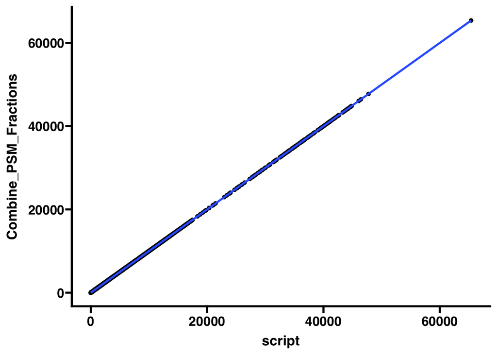

```r
data = read_csv("PSM_output_fractions_assigned.csv") %>%
  #These columns had different names for some reason
  dplyr::rename(Abundance..132N = "Abundance: 132N",
         Abundance..132C = "Abundance: 132C",
         Abundance..133N = "Abundance: 133N",
         Abundance..133C = "Abundance: 133C",
         Abundance..134N ="Abundance: 134N",
         PSM.Ambiguity ="PSM Ambiguity",
         Isolation.Interference.... = "Isolation Interference [%]",
         Spectrum.File = "Spectrum File",
         Master.Protein.Accessions = "Master Protein Accessions") %>%
  combine_psm_fractions_replica() %>%
  ungroup()


#Reading in the non normalized data that was output from the script
script_d = read_delim("CSVs_1/nonnormalizeddataall.txt") %>%
  pivot_longer(2:length(.)) %>%
  mutate(TMT = toupper(stringr::str_extract(name,"\\d\\d\\d[n|c|N|C]?"))) %>%
  mutate(Sample = stringr::str_extract(name,"DG\\d*")) %>%
  select(Sample,TMT,ProteinID,value) %>%
  mutate(method = "script")

#making output of combine_psm_fractions_replica compativle
cpsm = data %>%
  pivot_longer(3:length(.)) %>%
  mutate(TMT = stringr::str_extract(name,"\\d\\d\\d[n|c|N|C]?")) %>%
  select(Sample,TMT,ProteinID = Master.Protein.Accessions,value) %>%
  mutate(method = "Combine_PSM_Fractions")


comb = bind_rows(script_d,cpsm) %>%
  pivot_wider(names_from = method, values_from = value)


p1 = comb %>%
  ggplot(aes(script,Combine_PSM_Fractions))+
  geom_point()+
  geom_smooth(method = "lm")

p1
```

**Figure 1.** Here we can see that as expected, the results of combine_psm_fractions_replica exactly match the output of the script that we have previously used. This is encouraging, and means that this function is actually adaptable to our data.

Now we need to compare the normalization method that I have reverse engineered. How does that compare to the previous script?

Now we can compare the results from the two. Does our new function do what we think it does?

```r
##Here is the original code I used to trouble shoot
data = read_csv("PSM_output_fractions_assigned.csv") %>%
  #These columns had different names for some reason
  dplyr::rename(Abundance..132N = "Abundance: 132N",
         Abundance..132C = "Abundance: 132C",
         Abundance..133N = "Abundance: 133N",
         Abundance..133C = "Abundance: 133C",
         Abundance..134N ="Abundance: 134N",
         PSM.Ambiguity ="PSM Ambiguity",
         Isolation.Interference.... = "Isolation Interference [%]",
         Spectrum.File = "Spectrum File",
         Master.Protein.Accessions = "Master Protein Accessions") %>%
  combine_psm_fractions_replica() %>%
  ungroup() %>%
  pivot_longer(3:length(.)) %>%
  mutate(TMT = stringr::str_extract(name,"\\d\\d\\d[n|c|N|C]?")) %>%
  select(Sample,TMT,ProteinID = Master.Protein.Accessions,value)

#Broken down normalize to bridge function.
#Setting variable
bridge_channel_plex = "126"

#Taking the median of the bridge channel
Bridge_median = data %>%
  filter(TMT == bridge_channel_plex) %>%
  pull() %>%
  median(na.rm=TRUE)

#filtering for just the bridge values so we can append them later
bridge_values = data %>%
  filter(TMT == bridge_channel_plex) %>%
  select(-TMT) %>%
  dplyr::rename(bridge_values = value)

#appending bridge values. For each sample/TMT combination the
norm_bridge = inner_join(data,bridge_values,by = c("ProteinID","Sample")) %>%
  dplyr::mutate(norm_Abundance_1 = value / (bridge_values /Bridge_median)) %>%
  dplyr::ungroup() %>%
  filter(TMT != bridge_channel_plex)

#here data has been normalized to bridge. This matches the results from subset2 in origninal code

#Here we are pulling out the data from all plexes and taking the median for each
median_overall = norm_bridge %>%
  pull(norm_Abundance_1) %>%
  median(na.rm=T)

# medians per sample and plex
sample_plex_medians = norm_bridge %>%
  dplyr::ungroup() %>%
  dplyr::group_by(Sample,TMT) %>%
  dplyr::summarise(sample_plex_medians = median(norm_Abundance_1,na.rm=T))


#combining medians with data frame
norm_bridge = norm_bridge %>%
  inner_join(sample_plex_medians,by=c("TMT","Sample"))


output = norm_bridge %>%
  mutate(norm_Abundance_2 = norm_Abundance_1 / (sample_plex_medians / median_overall))


###Now let's pull in the normalized data from the script output
script_norm = read_delim("CSVs_1/NormalizedDataAll.txt") %>%
  pivot_longer(2:length(.)) %>%
  mutate(TMT = toupper(stringr::str_extract(name,"\\d\\d\\d[n|c|N|C]?"))) %>%
  mutate(Sample = stringr::str_extract(name,"DG\\d*")) %>%
  select(Sample,TMT,ProteinID,value) %>%
  dplyr::rename(norm_Abundance_2 = value) %>%
  mutate(method = "script")

output2 = output %>%
  select(Sample,TMT,ProteinID,norm_Abundance_2) %>%
  mutate(method = "normalize_to_bridge")

#Plot comparison
comb = bind_rows(script_norm,output2) %>%
  pivot_wider(names_from = method, values_from = norm_Abundance_2)


p1 = comb %>%
  ggplot(aes(script,normalize_to_bridge))+
  geom_point()+
  geom_abline(slope = 1, linetype = "dashed")+
  geom_smooth(method = "lm")

p1
```

[output not shown]

```r
#Here is the finalized psm fraction combining function ( gives same results as original)
combine_psm_fractions_replica = function(data){

  #Filtering to only keep high quality PSMs based on the criteria from Jacob's script
  fdata = data %>%
    #Replacing the same columns as the previous code with 1s. I am pretty sure that this is a bug and shouldn't be done.
    mutate(Abundance..132N = tidyr::replace_na(Abundance..132N,replace = 1),
           Abundance..132C = tidyr::replace_na(Abundance..132C,replace = 1),
           Abundance..133N = tidyr::replace_na(Abundance..133N,replace = 1),
           Abundance..133C = tidyr::replace_na(Abundance..133C,replace = 1),
           Abundance..134N = tidyr::replace_na(Abundance..134N,replace = 1)) %>%
    #Taking the average across all of the TMT channels
    #is this correct? Not sure why this makes sense to do. Is this really signal to noise?
    mutate(n_NA = rowSums(is.na(select(., contains("Abundance"))))) %>%
    mutate(AvgSN = rowMeans(select(., contains("Abundance")), na.rm = TRUE)) %>%
    filter(PSM.Ambiguity != "Rejected",
           Isolation.Interference.... < 30,
           AvgSN >= 10) %>%
    #Spliting the file name into plexs
    mutate(Sample = stringr::str_split(Spectrum.File,"_",simplify = T)[,1],
           Fraction = stringr::str_extract(Spectrum.File, "F[:digit:]")) %>%
    #Taking only the first Protein Accession listed in the Master.Protein.Accession Column
    mutate(Master.Protein.Accessions = stringr::str_split(Master.Protein.Accessions,";",simplify = T)[,1]) %>%
    #This really makes the output more similar. Looks like Previous script just obmits all NAs.
    filter(n_NA == 0)

  #Combining all of the PSMs from each sample
  output = fdata %>%
    select(Sample,Fraction,Master.Protein.Accessions,contains("Abundance")) %>%
    tidyr::pivot_longer(4:length(.)) %>%
    dplyr::group_by(Sample,ProteinID = Master.Protein.Accessions,name) %>%
    dplyr::summarise(value = sum(value,na.rm=T)) %>%
    dplyr::mutate(TMT = stringr::str_extract(name,"\\d\\d\\d[n|c|N|C]?")) %>%
    dplyr::select(Sample,TMT,ProteinID,value) %>%
    dplyr::ungroup()


  return(output)
}
```

```r
#Here is the finalized function that does the same thing as the original script
normalize_to_bridge = function(data = dataframe, bridge_channel_plex = "126"){
#The normalization is done as follows:
  #First we need to normalize the bridge channel by dividing each value by the median of the overall values within the bridge
  #Then we need to normalize our data to the normalized bridge values. We do this by dividing the values by the normalized bridge values
  #Lastly, we need to normalize all of the plexes. We can do this by dividing the value that has been normalized to the bridge channel plex by the column medians (for each plex) and then the overall median.
  Bridge_median = data %>%
    dplyr::filter(TMT == bridge_channel_plex) %>%
    dplyr::pull() %>%
    median(na.rm=TRUE)

  #filtering for just the bridge values so we can append them later
  bridge_values = data %>%
    dplyr::filter(TMT == bridge_channel_plex) %>%
    dplyr::select(-TMT) %>%
    dplyr::rename(bridge_values = value)

  #appending bridge values. For each sample/TMT combination the
  norm_bridge = dplyr::inner_join(data,bridge_values,by = c("ProteinID","Sample")) %>%
    dplyr::mutate(intermediate_norm = value / (bridge_values /Bridge_median)) %>%
    dplyr::ungroup() %>%
    dplyr::filter(TMT != bridge_channel_plex)

  #here data has been normalized to bridge. This matches the results from subset2 in original code

  #Here we are pulling out the data from all samples/plex combinations and taking the median for each.
  median_overall = norm_bridge %>%
    dplyr::pull(intermediate_norm) %>%
    median(na.rm=T)

  # medians per sample and plex
  sample_plex_medians = norm_bridge %>%
    dplyr::ungroup() %>%
    dplyr::group_by(Sample,TMT) %>%
    dplyr::summarise(sample_plex_medians = median(intermediate_norm,na.rm=T))


  #combining medians with data frame
  norm_bridge = norm_bridge %>%
    dplyr::inner_join(sample_plex_medians,by=c("TMT","Sample"))

  #Doing the final Normalization
  output = norm_bridge %>%
    dplyr::mutate(final_norm = intermediate_norm / (sample_plex_medians / median_overall))
}
```

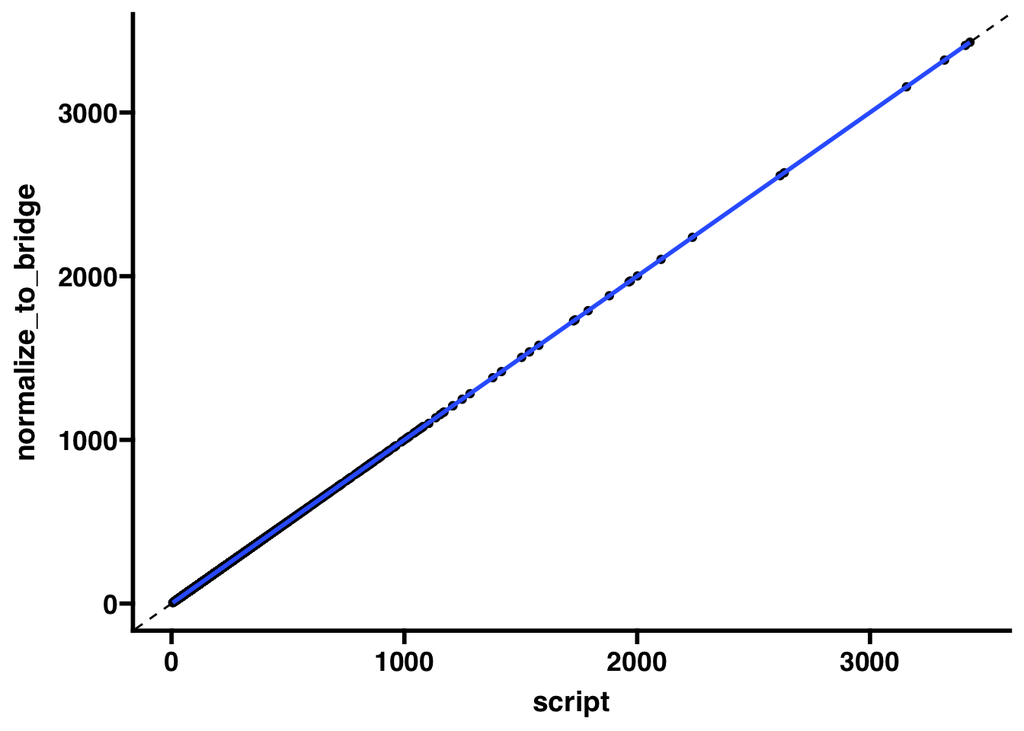

```r
#Now let's test everything...

data = read_csv("PSM_output_fractions_assigned.csv") %>%
  #These columns had different names for some reason
  dplyr::rename(Abundance..132N = "Abundance: 132N",
         Abundance..132C = "Abundance: 132C",
         Abundance..133N = "Abundance: 133N",
         Abundance..133C = "Abundance: 133C",
         Abundance..134N ="Abundance: 134N",
         PSM.Ambiguity ="PSM Ambiguity",
         Isolation.Interference.... = "Isolation Interference [%]",
         Spectrum.File = "Spectrum File",
         Master.Protein.Accessions = "Master Protein Accessions") %>%
  combine_psm_fractions_replica()


###Now let's pull in the normalized data from the script output
script_norm = read_delim("CSVs_1/NormalizedDataAll.txt") %>%
  pivot_longer(2:length(.)) %>%
  mutate(TMT = toupper(stringr::str_extract(name,"\\d\\d\\d[n|c|N|C]?"))) %>%
  mutate(Sample = stringr::str_extract(name,"DG\\d*")) %>%
  select(Sample,TMT,ProteinID,value) %>%
  dplyr::rename(final_norm = value) %>%
  mutate(method = "script")

output2 = read_csv("PSM_output_fractions_assigned.csv") %>%
  #These columns had different names for some reason
  dplyr::rename(Abundance..132N = "Abundance: 132N",
         Abundance..132C = "Abundance: 132C",
         Abundance..133N = "Abundance: 133N",
         Abundance..133C = "Abundance: 133C",
         Abundance..134N ="Abundance: 134N",
         PSM.Ambiguity ="PSM Ambiguity",
         Isolation.Interference.... = "Isolation Interference [%]",
         Spectrum.File = "Spectrum File",
         Master.Protein.Accessions = "Master Protein Accessions") %>%
  combine_psm_fractions_replica() %>%
  normalize_to_bridge() %>%
  mutate(method = "normalize_to_bridge") %>%
  select(Sample,TMT,ProteinID,final_norm,method)

#Plot comparison
comb = bind_rows(script_norm,output2) %>%
  pivot_wider(names_from = method, values_from = final_norm)


p1 = comb %>%
  ggplot(aes(script,normalize_to_bridge))+
  geom_point()+
  geom_abline(slope = 1, linetype = "dashed")+
  geom_smooth(method = "lm")

p1
```

**Figure 2** Here we can see that I have managed to exactly reproduce the normalization method that we use, using the above code (minuses some differences introduced by rounding error. This suggests that the code is ready to be added to the GLabR package.